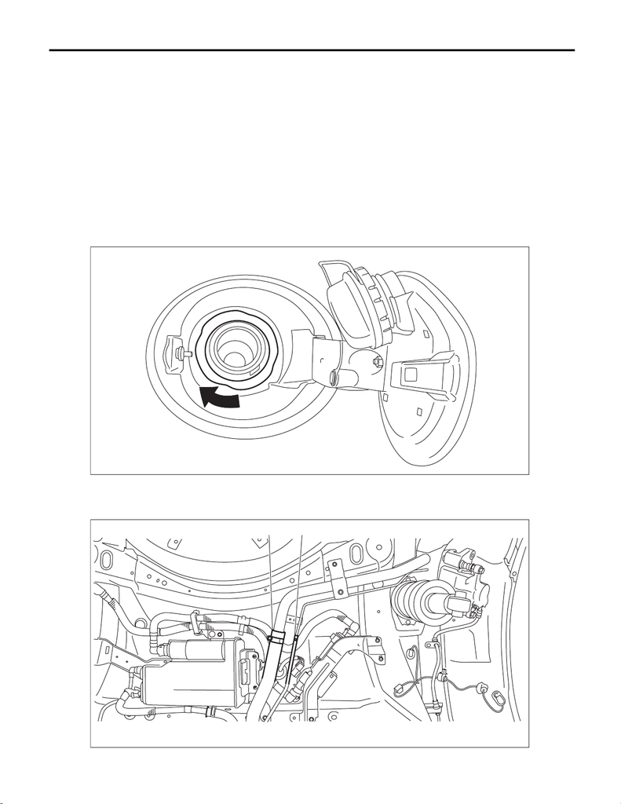

FU(STI)-77

Fuel Filler Pipe

FUEL INJECTION (FUEL SYSTEMS)

28.Fuel Filler Pipe

A: REMOVAL

WARNING:

Place “NO OPEN FLAMES” signs near the working area.

CAUTION:

Be careful not to spill fuel.

1) Release the fuel pressure. <Ref. to FU(STI)-64, RELEASING OF FUEL PRESSURE, PROCEDURE, Fu-

el.>

2) Drain fuel. <Ref. to FU(STI)-64, DRAINING FUEL (WITH SUBARU SELECT MONITOR), PROCEDURE,

Fuel.>

3) Disconnect the ground cable from battery.

4) Open the fuel filler lid and remove the fuel filler cap.

5) Turn the fuel filler pipe protector in the direction of the arrow to unlock and remove it.

6) Remove the rear sub frame assembly. <Ref. to RS-9, REMOVAL, Rear Sub Frame.>

7) Remove the rear mud guard RH. <Ref. to EI-23, REMOVAL, Mud Guard.>

8) Disconnect the fuel filler hose (A) and evaporation hose (B) from the fuel filler pipe assembly.

FU-08290

FU-08286

(A) (B)

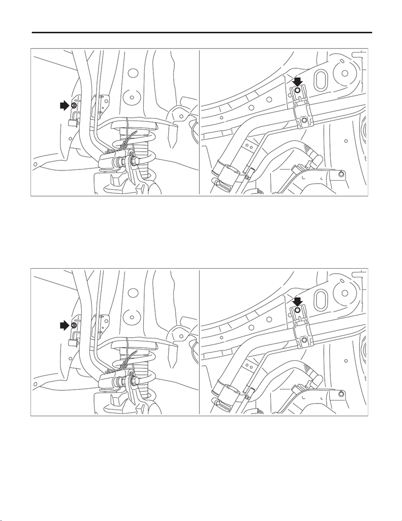

FU(STI)-78

Fuel Filler Pipe

FUEL INJECTION (FUEL SYSTEMS)

9) Remove the bolts and nuts which secure the fuel filler pipe assembly to the vehicle.

10) Remove the fuel filler pipe assembly from the underside of the vehicle.

B: INSTALLATION

1) Open the fuel filler lid.

2) Insert the fuel filler pipe assembly from inside of the rear fender.

3) Install the fuel filler pipe assembly to the vehicle.

Tightening torque:

7.5 N·m (0.8 kgf-m, 5.5 ft-lb)

FU-08287

FU-08287

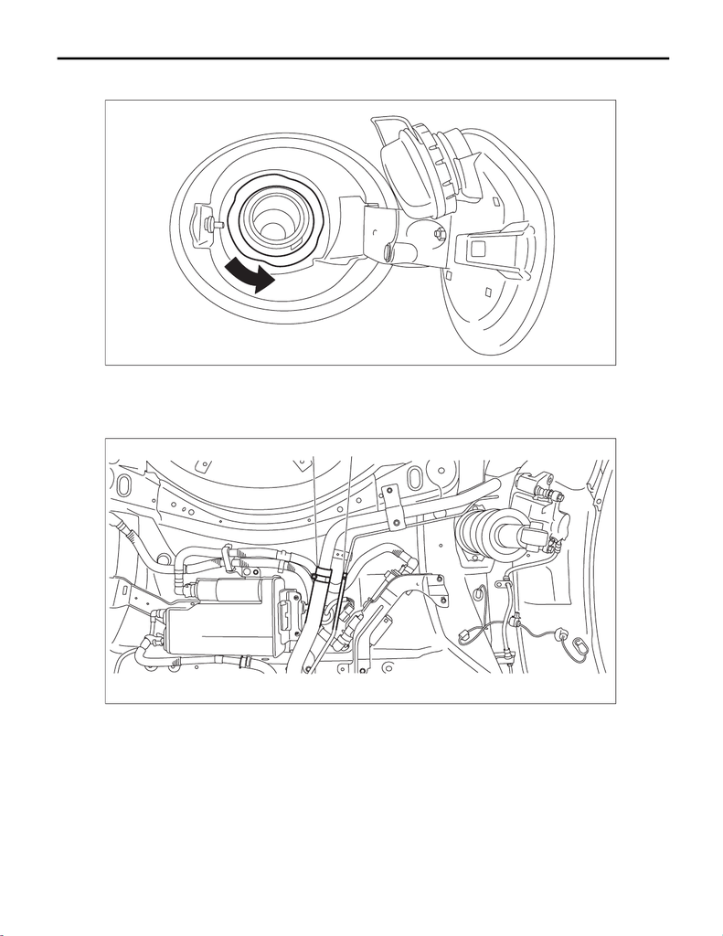

FU(STI)-79

Fuel Filler Pipe

FUEL INJECTION (FUEL SYSTEMS)

4) Align the cutout on the fuel filler pipe protector and the protrusion of the neck holder and insert them all the

way, and then turn the fuel filler pipe protector in the direction of the arrow until it is locked.

5) Securely insert the fuel filler hose (A) and evaporation hose (B) until the hose end contacts the spool, then

attach the clamp or clip as shown in the figure.

Tightening torque:

2.5 N·m (0.3 kgf-m, 1.8 ft-lb)

FU-08556

FU-08286

(A) (B)

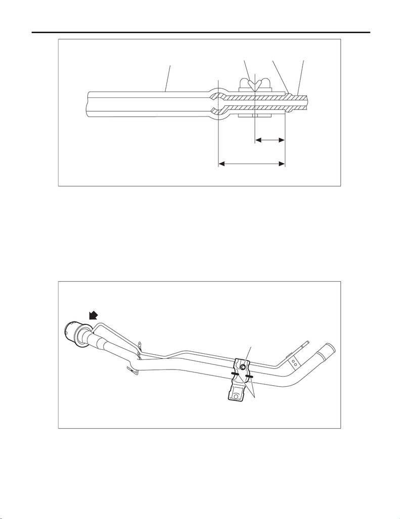

FU(STI)-80

Fuel Filler Pipe

FUEL INJECTION (FUEL SYSTEMS)

6) Install the rear mud guard RH. <Ref. to EI-24, INSTALLATION, Mud Guard.>

7) Install the rear sub frame assembly. <Ref. to RS-12, INSTALLATION, Rear Sub Frame.>

8) Connect the battery ground terminal.

C: DISASSEMBLY

1) Using a marker pen, make alignment marks (A) on the fuel filler pipe and the bracket.

2) Remove the bracket bolt (B) which secures the fuel filler pipe.

3) Remove the neck holder from the fuel filler pipe.

(1) Hose (3) Spool (4) Pipe

(2) Clamp or clip

L

L/2

(1)

(2)

(3)

(4)

FU-06185

FU-08288

(B)

(A)

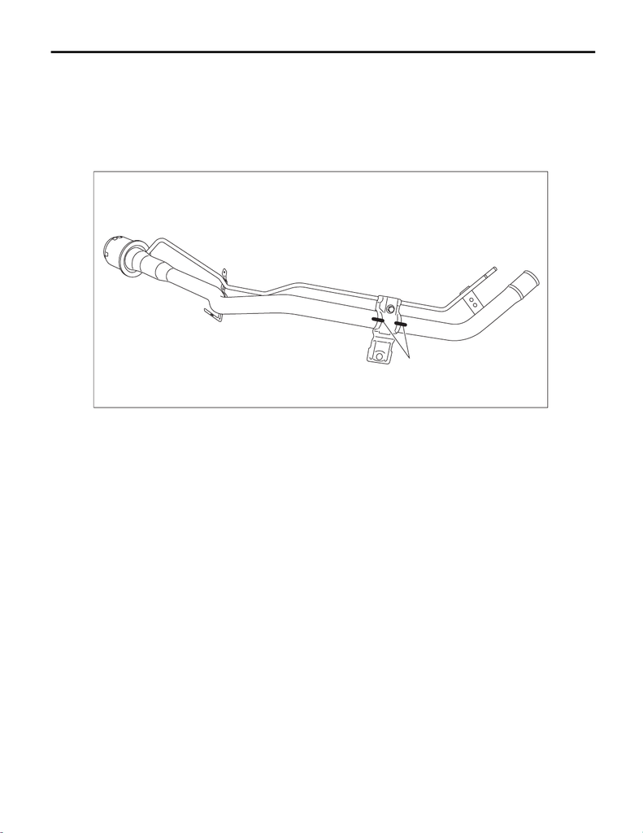

FU(STI)-81

Fuel Filler Pipe

FUEL INJECTION (FUEL SYSTEMS)

D: ASSEMBLY

Assemble in the reverse order of disassembly.

NOTE:

• Use a new neck holder.

• Install the bracket to the fuel filler pipe by aligning the alignment marks (A).

Tightening torque:

7.5 N·m (0.8 kgf-m, 5.5 ft-lb)

E: INSPECTION

1) Check that the fuel filler pipe assembly has no deformation, cracks or other damages.

2) Check that the fuel hose has no cracks, damage or loose part.

FU-08289

(A)